# Category Learning Data Processing

Kayleigh Ryherd

11/13/2018

Read in data, load libraries, set working directory.

```r
library(Rmisc)
library(tidyverse)
library(neuropsychology)
library(lme4)
library(lmerTest)
library(fBasics)
library(caret)
library(multcomp)
library(ggcorrplot)
library(multcomp)
setwd("~/dissertation/DataAnalysis/Exp2/CatLearning")
ashby <- read.csv("Ashby_concat_12-07-18_1019.csv")
sloutsky <- read.csv("Sloutsky_concat_12-07-18_1019.csv")
taxthem <- read.csv("taxthem_concat_12-07-18_1020.csv")
age_gender <- read.csv("../age_gender.csv")
```

# Processing/Standardizing Ashby Data

```r
# check block names
levels(as.factor(ashby$Block))
```

```
## [1] "1"  "2"  "3"  "4"  "33"
```

```r
# edit typo
ashby$Block[ashby$Block == 33] <- 3
# create across-block trial value
ashby$Overall_Trial <- (ashby$Block-1)*80 + ashby$Trial
# select only blocks 1 - 3
ashby_filt <- dplyr::filter(ashby, Block <= 3)
```

Check to see which subjects have missing blocks & remove those subjects. This means any subject with less than 240 trials (3 full blocks) is dropped.

```r
complete <- ashby_filt %>%
  group_by(Subject, Type) %>%
  summarise(count = n()) %>%
  dplyr::filter(count == 240) %>%
  spread(key = Type, value = count) %>%
  na.omit
nrow(complete)
```

```
## [1] 115
```

```r
complete_ashby_blocks <- complete$Subject
ashby_full <- ashby_filt %>%
  dplyr::filter(Subject %in% complete_ashby_blocks)
```

## Accuracy

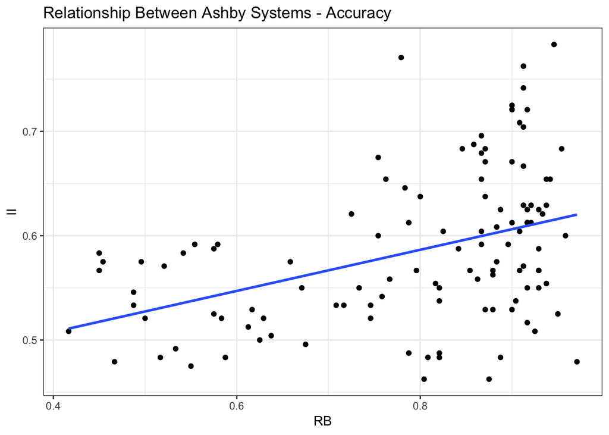

```r
# mean accuracy by subject and system
ashby_acc_long <- ashby_full %>%
  group_by(Subject, Type) %>%
  summarise(m_acc = mean(Accuracy))

# plot relationship between systems
ashby_acc_wide <- spread(ashby_acc_long, Type, m_acc)
ggplot(ashby_acc_wide, aes(RB, II)) + geom_point() + theme_bw() + geom_smooth(method = "lm", se = FALSE) +
  ggtitle("Relationship Between Ashby Systems - Accuracy")
```

```r
# test correlation
cor.test(ashby_acc_wide$RB, ashby_acc_wide$II)
```

```
##
##  Pearson's product-moment correlation
##
## data:  ashby_acc_wide$RB and ashby_acc_wide$II
## t = 4.7633, df = 113, p-value = 5.698e-06
## alternative hypothesis: true correlation is not equal to 0
## 95 percent confidence interval:
##  0.2440863 0.5507889
## sample estimates:
##       cor
## 0.4089202
```

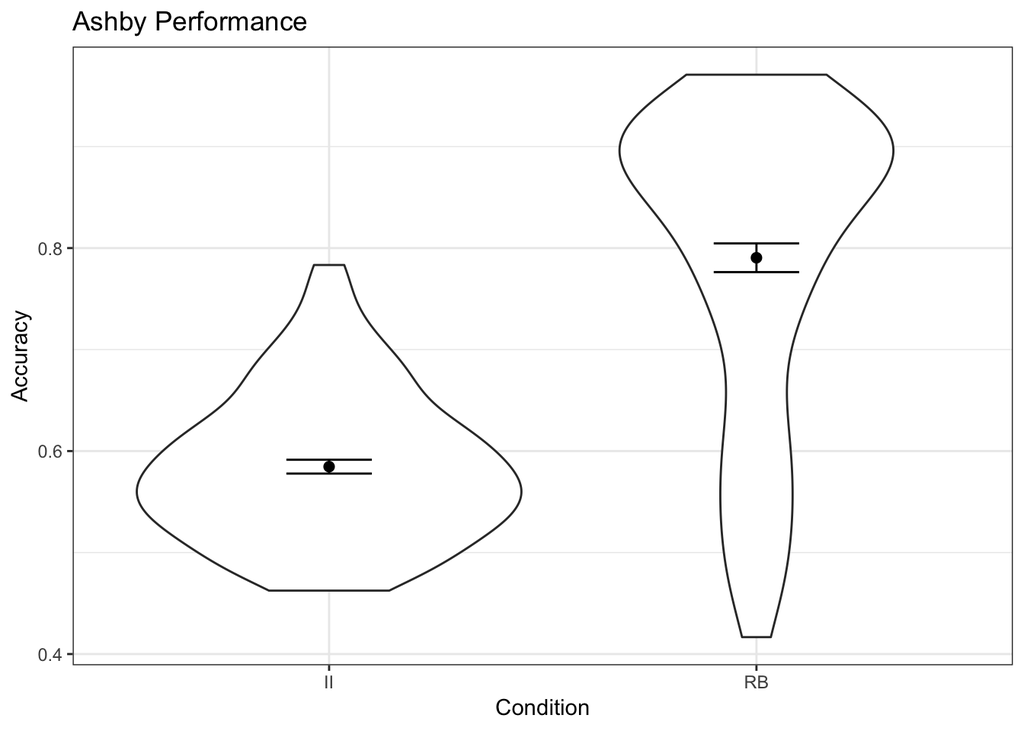

```r
# violin plot by system
ashby_acc_plot <- summarySE(ashby_acc_long, "m_acc", "Type")
ggplot(ashby_acc_long, aes(Type, m_acc)) + geom_violin() +
  geom_point(aes(y = m_acc), size = 2, position = position_dodge((width = 0.90)), data = ashby_acc_plot) +
  geom_errorbar(aes(ymin = m_acc-se, ymax = m_acc+se), width = 0.20, position = position_dodge((width = 0.90)), data = ashby_acc_plot) +
  theme_bw() + xlab("Condition") + ylab("Accuracy") + ggtitle("Ashby Performance")
```

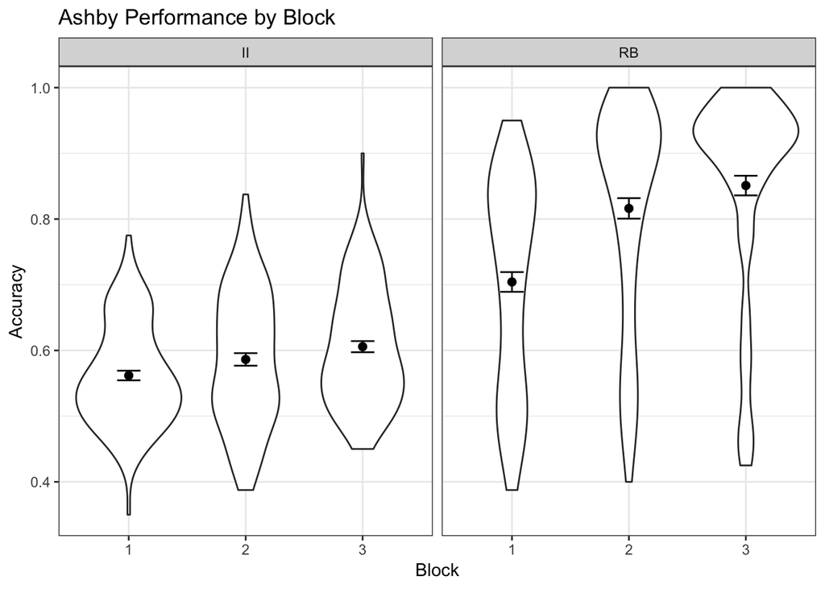

```r
# summarize by block, system, and subject
ashby_acc_block <- ashby_full %>%
  group_by(Subject, Type, Block) %>%
  summarise(m_acc = mean(Accuracy))
ashby_acc_block$Block <- as.factor(ashby_acc_block$Block)

# plot by system and block
ashby_acc_plot <- summarySE(ashby_acc_block, "m_acc", c("Type", "Block"))
ggplot(ashby_acc_block, aes(Block, m_acc)) + geom_violin() +
  geom_point(aes(y = m_acc), size = 2, position = position_dodge((width = 0.90)), data = ashby_acc_plot) +
  geom_errorbar(aes(ymin = m_acc-se, ymax = m_acc+se), width = 0.20, position = position_dodge((width = 0.90)), data = ashby_acc_plot) +
  facet_grid(.~Type) +
  theme_bw() + xlab("Block") + ylab("Accuracy") + ggtitle("Ashby Performance by Block")
```

Create *z*-scores for accuracy.

```r
# select new data frame
ashby_acc_stand <- ashby_acc_long
# z-scores
ashby_acc_stand$acc_z <- scale(ashby_acc_stand$m_acc)
# create column for system
ashby_acc_stand$System <- NA
ashby_acc_stand$System[ashby_acc_stand$Type == "II"] <- "associative"
ashby_acc_stand$System[ashby_acc_stand$Type == "RB"] <- "hypothesis-testing"
# create column for paradigm
ashby_acc_stand$CatLearn <- "ashby"
# create df with raw ACC values
ashby_acc <- ashby_acc_stand[,-c(2,4)]
# create df with ACC z-scores
ashby_acc_stand <- ashby_acc_stand[,-c(2,3)]
```

## RT

RT Filtering (Lachaud & Renaud, 2011)

- ideal: +/- 2SD by item and by subject
- can’t do by item, but we can do by subject nd type (RB vs II).

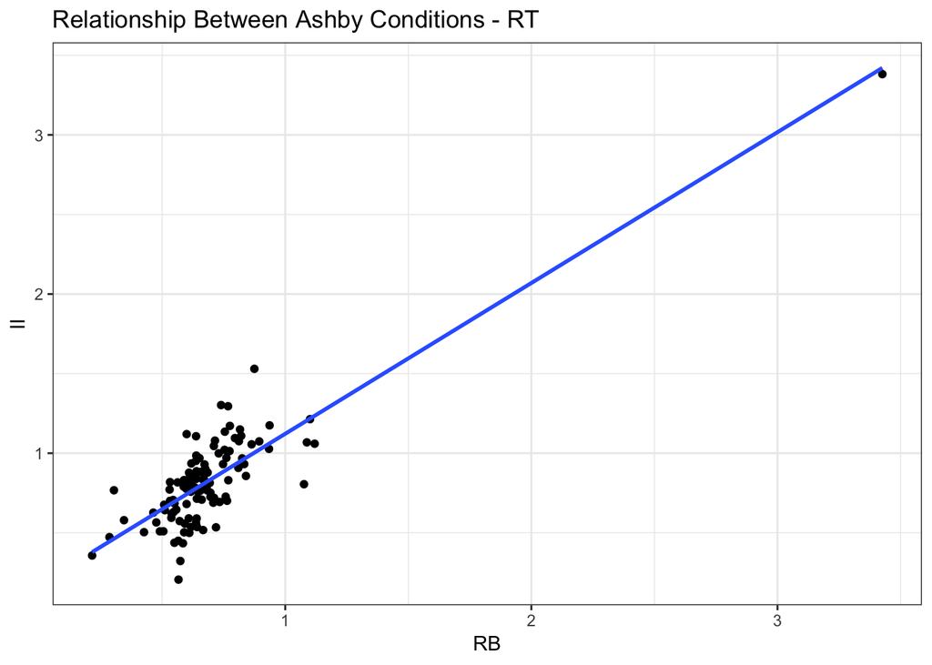

```r
# filter RTs and then calculate mean RT by subject
ashby_rt_long <- ashby_full %>%
  dplyr::filter(Accuracy == 1) %>% # selecting correct trials only
  group_by(Subject, Type) %>%
  mutate(mean_rt = mean(RT),
         sd_rt = sd(RT),
         diff = RT-mean_rt,
         remove = ifelse(abs(diff) > 2*sd_rt, 1, 0)) %>% # if any trial has an RT more than 2SD away from the mean, flag it for removal
  dplyr::filter(remove == 0) %>% # remove those trials
  summarise(m_rt = mean(RT))

ashby_rt_wide <- spread(ashby_rt_long, Type, m_rt)
ggplot(ashby_rt_wide, aes(RB, II)) + geom_point() + theme_bw() + geom_smooth(method = "lm", se = FALSE) +
  ggtitle("Relationship Between Ashby Conditions - RT")
```

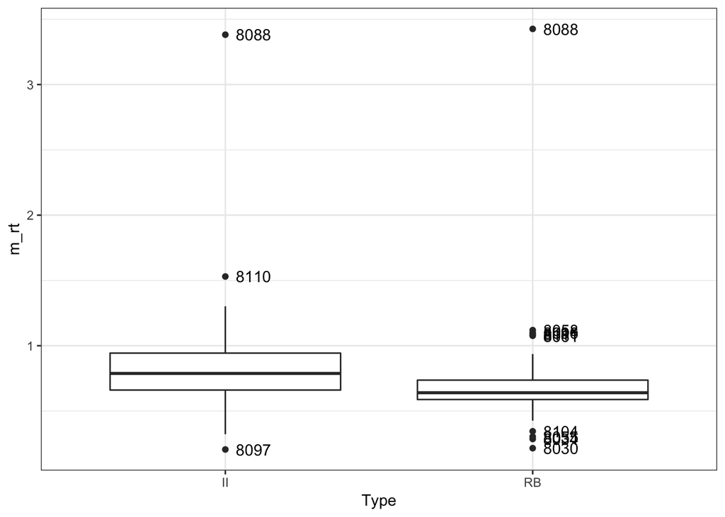

```r
# check for subjects who are total outliers within a given system

is_outlier <- function(x) {
  return(x < quantile(x, 0.25) - 1.5 * IQR(x) | x > quantile(x, 0.75) + 1.5 * IQR(x))
}
ashby_rt_long %>%
  group_by(Type) %>%
  mutate(outlier = ifelse(is_outlier(m_rt), Subject, as.numeric(NA))) %>%
  ggplot(., aes(Type, m_rt)) + geom_boxplot() + geom_text(aes(label = outlier), na.rm = TRUE, hjust = -0.3) + theme_bw()
```

One subject has weirdly long RTs for both systems. I’m going to remove them from the analysis.

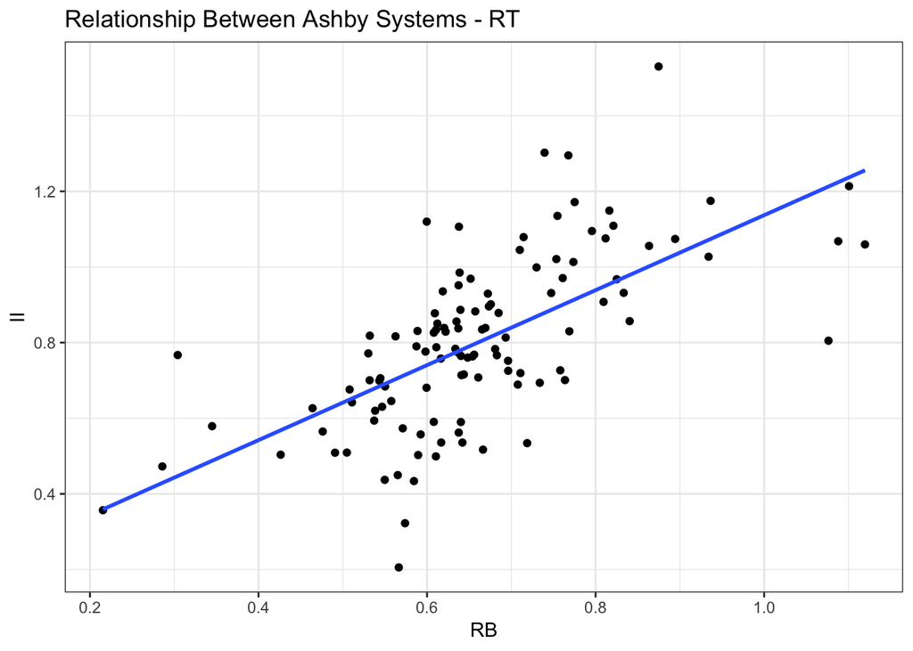

```r
ashby_rt_long <- ashby_rt_long %>%
  dplyr::filter(Subject != 8088)

ashby_rt_wide <- ashby_rt_wide %>%
  dplyr::filter(Subject != 8088)

# plot relationship between two systems
ggplot(ashby_rt_wide, aes(RB, II)) + geom_point() + theme_bw() + geom_smooth(method = "lm", se = FALSE) +
  ggtitle("Relationship Between Ashby Systems - RT")
```

```r
# test correlation
cor.test(ashby_rt_wide$RB, ashby_rt_wide$II)
```

```
##
##  Pearson's product-moment correlation
##
## data:  ashby_rt_wide$RB and ashby_rt_wide$II
## t = 8.9846, df = 112, p-value = 7.247e-15
## alternative hypothesis: true correlation is not equal to 0
## 95 percent confidence interval:
##  0.5258673 0.7427020
## sample estimates:
##       cor
## 0.6471893
```

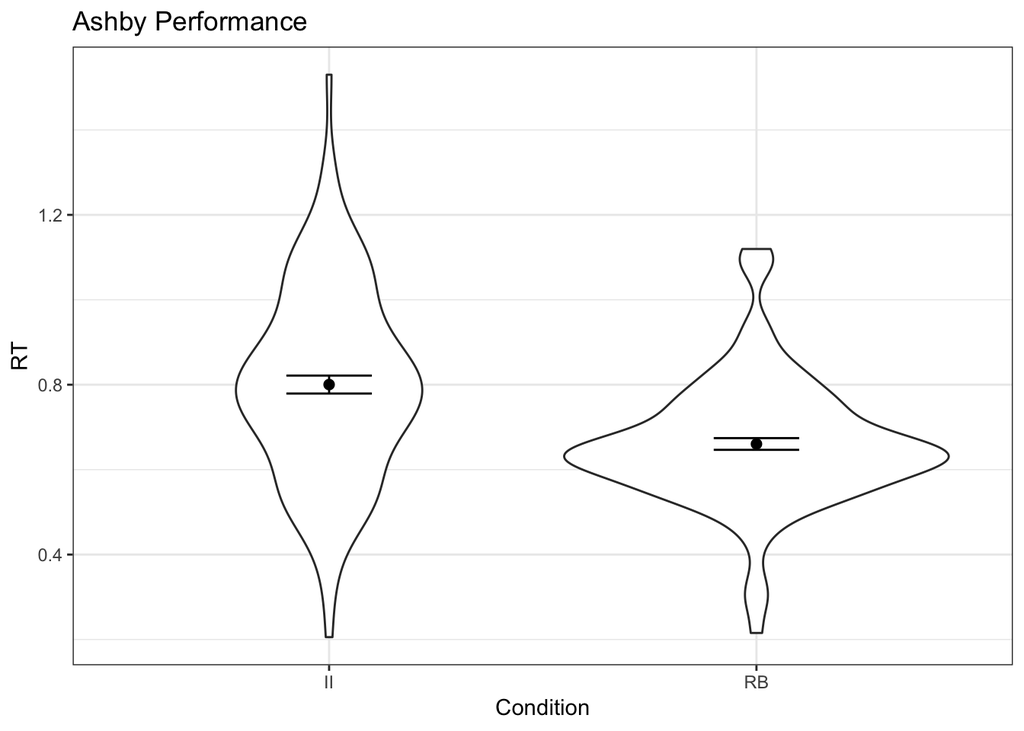

```r
# violin plot of RTs by system
ashby_rt_plot <- summarySE(ashby_rt_long, "m_rt", "Type")
ggplot(ashby_rt_long, aes(Type, m_rt)) + geom_violin() +
  geom_point(aes(y = m_rt), size = 2, position = position_dodge((width = 0.90)), data = ashby_rt_plot) +
  geom_errorbar(aes(ymin = m_rt-se, ymax = m_rt+se), width = 0.20, position = position_dodge((width = 0.90)), data = ashby_rt_plot) +
  theme_bw() + xlab("Condition") + ylab("RT") + ggtitle("Ashby Performance")
```

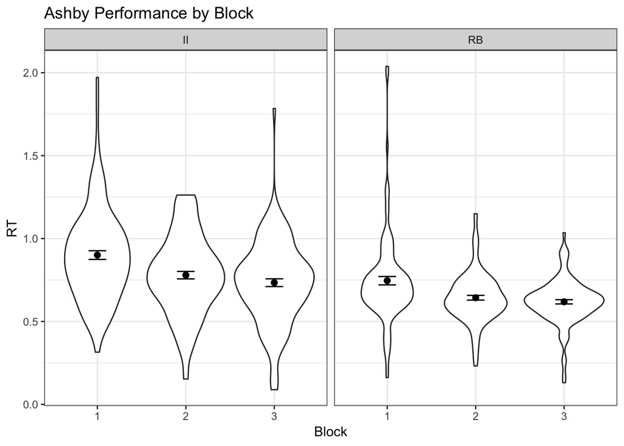

```r
# summarise by subject, system, and block
ashby_rt_block <- ashby_full %>%
  dplyr::filter(Accuracy == 1, Subject != 8088) %>% # selecting correct trials only, removing outlier subject
  group_by(Subject, Type, Block) %>%
  mutate(mean_rt = mean(RT),
         sd_rt = sd(RT),
         diff = RT-mean_rt,
         remove = ifelse(abs(diff) > 2*sd_rt, 1, 0)) %>%
  dplyr::filter(remove == 0) %>%
  summarise(m_rt = mean(RT))
ashby_rt_block$Block <- as.factor(ashby_rt_block$Block)

# plot by block and system
ashby_rt_plot <- summarySE(ashby_rt_block, "m_rt", c("Type", "Block"))
ggplot(ashby_rt_block, aes(Block, m_rt)) + geom_violin() +
  geom_point(aes(y = m_rt), size = 2, position = position_dodge((width = 0.90)), data = ashby_rt_plot) +
  geom_errorbar(aes(ymin = m_rt-se, ymax = m_rt+se), width = 0.20, position = position_dodge((width = 0.90)), data = ashby_rt_plot) +
  facet_grid(.~Type) +
  theme_bw() + xlab("Block") + ylab("RT") + ggtitle("Ashby Performance by Block")
```

```r
# select new df
ashby_rt_stand <- ashby_rt_long
# create z-scores
ashby_rt_stand$rt_z <- scale(ashby_rt_stand$m_rt)
# create column for system
ashby_rt_stand$System <- NA
ashby_rt_stand$System[ashby_rt_stand$Type == "II"] <- "associative"
ashby_rt_stand$System[ashby_rt_stand$Type == "RB"] <- "hypothesis-testing"
# create column for paradigm
ashby_rt_stand$CatLearn <- "ashby"
# df with raw RTs
ashby_rt <- ashby_rt_stand[,-c(2,4)]
# df with RT z-scores
ashby_rt_stand <- ashby_rt_stand[,-c(2:3)]
```

# Processing/Standardizing Sloutsky Data

## Accuracy

I have used d’ in the past, but I want this to be totally relatable between tasks. I’m going to calculate regular accuracy here.

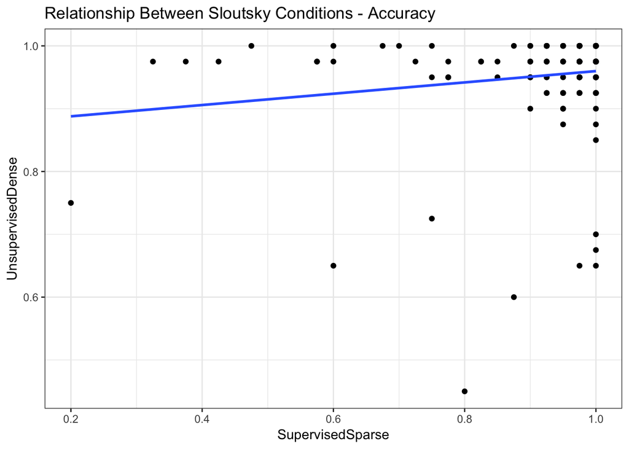

```r
# summarize ACCs by subject and system
sloutsky_acc_long <- sloutsky %>%
  group_by(Subject, Block) %>%
  summarise(m_acc = mean(Accuracy))

# plot relationship between systems
sloutsky_acc_wide <- spread(sloutsky_acc_long, Block, m_acc)
ggplot(sloutsky_acc_wide, aes(SupervisedSparse, UnsupervisedDense)) + geom_point() + theme_bw() + geom_smooth(method = "lm", se = FALSE) +
  ggtitle("Relationship Between Sloutsky Conditions - Accuracy")
```

```r
# test correlation
cor.test(sloutsky_acc_wide$SupervisedSparse, sloutsky_acc_wide$UnsupervisedDense)
```

```
##
##  Pearson's product-moment correlation
##
## data:  sloutsky_acc_wide$SupervisedSparse and sloutsky_acc_wide$UnsupervisedDense
## t = 1.8367, df = 147, p-value = 0.06828
## alternative hypothesis: true correlation is not equal to 0
## 95 percent confidence interval:
##  -0.01129454  0.30327329
## sample estimates:
##       cor
## 0.1497774
```

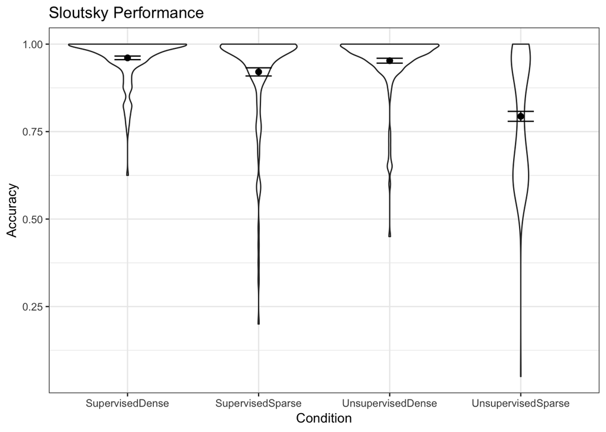

```r
# violin plot of systems
sloutsky_acc_plot <- summarySE(sloutsky_acc_long, "m_acc", "Block")
ggplot(sloutsky_acc_long, aes(Block, m_acc)) + geom_violin() +
  geom_point(aes(y = m_acc), size = 2, position = position_dodge((width = 0.90)), data = sloutsky_acc_plot) +
  geom_errorbar(aes(ymin = m_acc-se, ymax = m_acc+se), width = 0.20, position = position_dodge((width = 0.90)), data = sloutsky_acc_plot) +
  theme_bw() + xlab("Condition") + ylab("Accuracy") + ggtitle("Sloutsky Performance")
```

Create *z*-scores for accuracy.

```r
# select only relevant blocks, create new df
slout_acc_stand <- sloutsky_acc_long %>%
  dplyr::filter(Block == "SupervisedSparse" | Block == "UnsupervisedDense") %>%
  dplyr::select(Subject, Block, m_acc)
# z-scores
slout_acc_stand$acc_z <- scale(slout_acc_stand$m_acc)
# create column for system
slout_acc_stand$System <- NA
slout_acc_stand$System[slout_acc_stand$Block == "UnsupervisedDense"] <- "associative"
slout_acc_stand$System[slout_acc_stand$Block == "SupervisedSparse"] <- "hypothesis-testing"
# create column for paradigm
slout_acc_stand$CatLearn <- "sloutsky"
# df with raw acc
slout_acc <- slout_acc_stand[,-c(2,4)]
# df with acc z-scores
slout_acc_stand <- slout_acc_stand[,-c(2,3)]
```

## RT

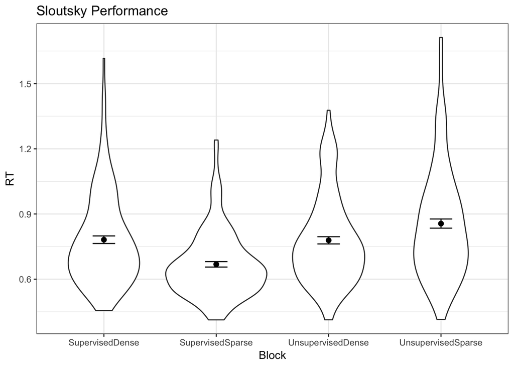

```r
# recode non-answers to missing
sloutsky$RT[sloutsky$RT == 9999] <- NA

# same RT processing as above
sl_rt <- sloutsky %>%
  dplyr::filter(Accuracy == 1) %>%
  group_by(Subject, Block) %>%
  mutate(mean_rt = mean(RT),
         sd_rt = sd(RT),
         diff = RT-mean_rt,
         remove = ifelse(abs(diff) > 2*sd_rt, 1, 0)) %>%
  dplyr::filter(remove == 0) %>%
  summarise(m_rt = mean(RT))

# plot by system
sl_plot_rt <- summarySE(sl_rt, "m_rt", "Block", na.rm = TRUE)
ggplot(sl_rt, aes(Block, m_rt)) + geom_violin() +
  geom_point(aes(y = m_rt), size = 2, position = position_dodge((width = 0.90)), data = sl_plot_rt) +
  geom_errorbar(aes(ymin = m_rt-se, ymax = m_rt+se), width = 0.20, position = position_dodge((width = 0.90)), data = sl_plot_rt) +
  theme_bw() + xlab("Block") + ylab("RT") + ggtitle("Sloutsky Performance")
```

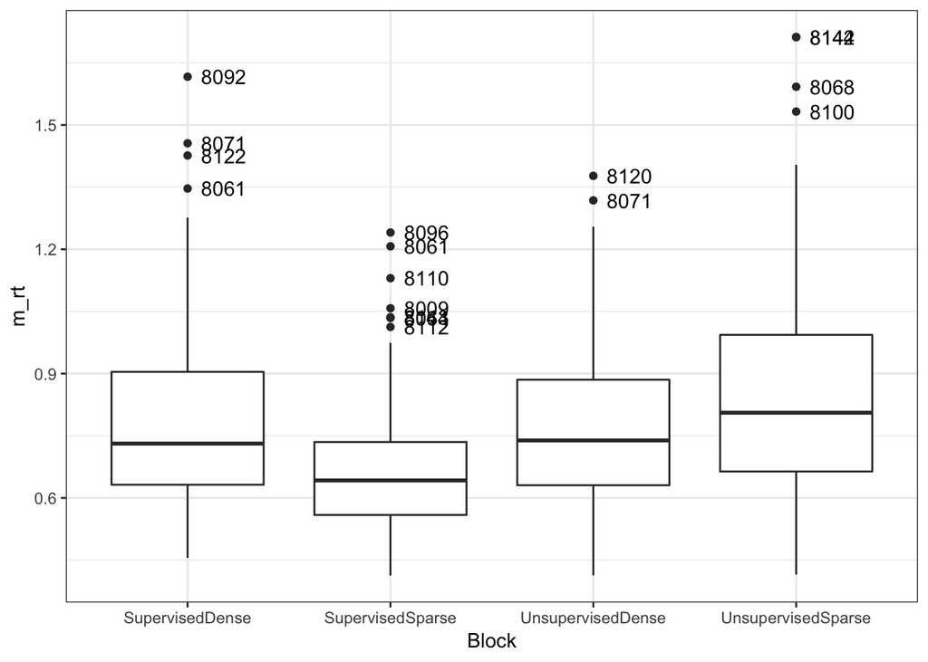

```r
# plot to look for outliers
sl_rt %>%
  group_by(Block) %>%
  mutate(outlier = ifelse(is_outlier(m_rt), Subject, as.numeric(NA))) %>%
  ggplot(., aes(Block, m_rt)) + geom_boxplot() + geom_text(aes(label = outlier), na.rm = TRUE, hjust = -0.3) + theme_bw()
```

Here the RTs make sense – Supervised (hypothesis-testing) is faster than unsupervised (associative), and match (SS and UD) are faster than mismatch (SD and US).

No single subject is an outlier across all conditions, so I won’t be removing anyone.

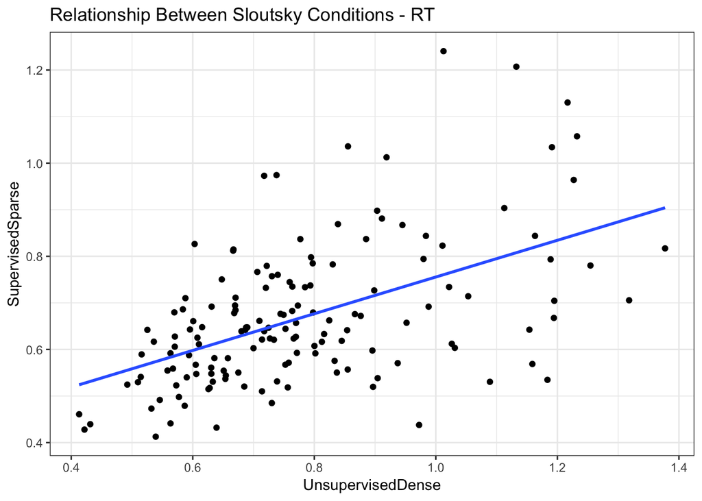

```r
# select relevant blocks and plot relationship between the two
sl_filt <- dplyr::filter(sl_rt, Block %in% c("SupervisedSparse","UnsupervisedDense"))
sl_wide <- spread(sl_filt, Block, m_rt)
ggplot(sl_wide, aes(UnsupervisedDense, SupervisedSparse)) + geom_point() + theme_bw() +
  geom_smooth(method = "lm", se = FALSE) +
  ggtitle("Relationship Between Sloutsky Conditions - RT")
```

Standardizing Sloutsky RTs.

```r
# select new df
slout_rt_stand <- sl_filt
# z-scores
slout_rt_stand$rt_z <- scale(slout_rt_stand$m_rt)
# column for system
slout_rt_stand$System <- NA
slout_rt_stand$System[slout_rt_stand$Block == "UnsupervisedDense"] <- "associative"
slout_rt_stand$System[slout_rt_stand$Block == "SupervisedSparse"] <- "hypothesis-testing"
# column for paradigm
slout_rt_stand$CatLearn <- "sloutsky"
# df for raw RT
slout_rt <- slout_rt_stand[,-c(2,4)]
# df for RT z-scores
slout_rt_stand <- slout_rt_stand[,-c(2,3)]
```

# Processing/Standardizing Tax/Them Data

## Accuracy

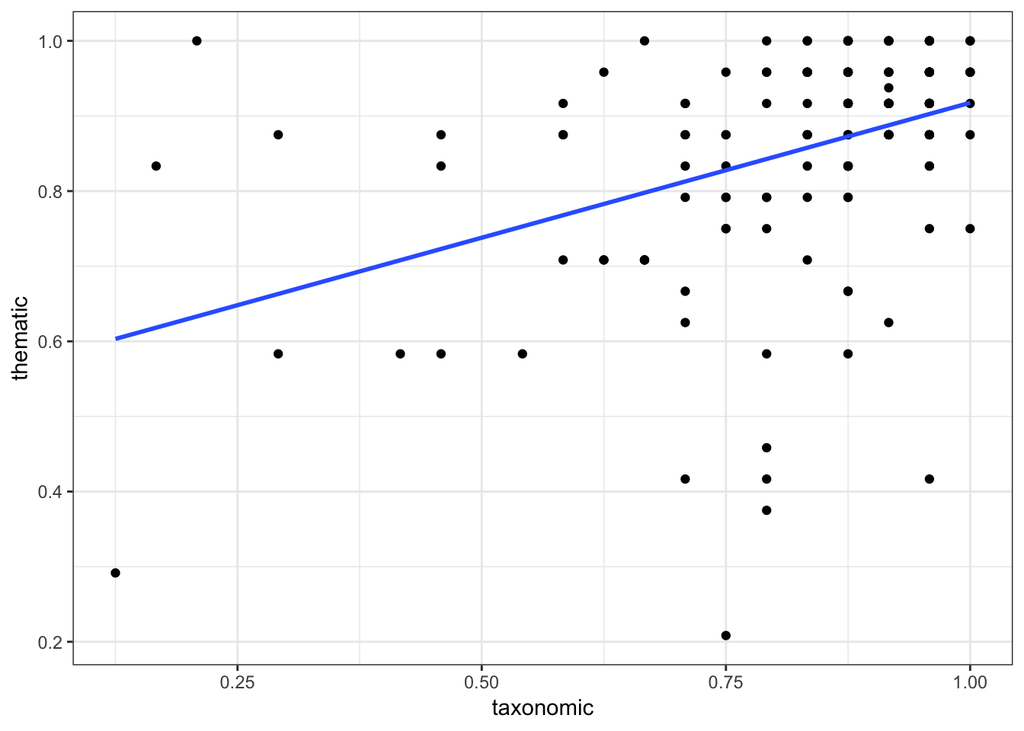

```r
# select only the test trials
test_trials <- dplyr::filter(taxthem, !is.na(expTrials.thisTrialN))

# calculate mean acc by participant and system
tt_acc <- test_trials %>%
  group_by(participant, Experiment) %>%
  summarise(m_acc = mean(resp.corr))

# plot relationship between two systems
tt_acc_wide <- tt_acc %>%
  group_by(participant) %>%
  spread(key = Experiment, value = m_acc)
ggplot(tt_acc_wide, aes(taxonomic, thematic)) + geom_point() + geom_smooth(se = FALSE, method = "lm") + theme_bw()
```

```r
# test correlation
cor.test(tt_acc_wide$taxonomic, tt_acc_wide$thematic)
```

```
##
##  Pearson's product-moment correlation
##
## data:  tt_acc_wide$taxonomic and tt_acc_wide$thematic
## t = 5.2131, df = 149, p-value = 6.097e-07
## alternative hypothesis: true correlation is not equal to 0
## 95 percent confidence interval:
##  0.2486275 0.5198728
## sample estimates:
##       cor
## 0.3927584
```

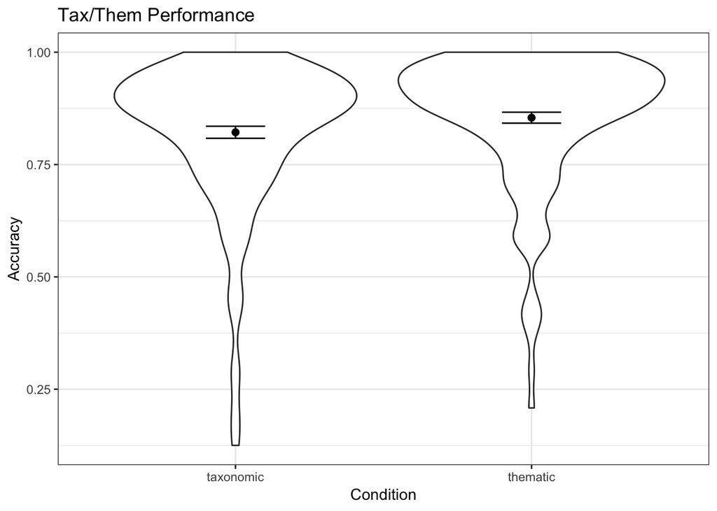

```r
# violin plot of both systems
tt_plot_acc <- summarySE(tt_acc, "m_acc", "Experiment")
ggplot(tt_acc, aes(Experiment, m_acc)) + geom_violin() +
  geom_point(aes(y = m_acc), size = 2, position = position_dodge((width = 0.90)), data = tt_plot_acc) +
  geom_errorbar(aes(ymin = m_acc-se, ymax = m_acc+se), width = 0.20, position = position_dodge((width = 0.90)), data = tt_plot_acc) +
  theme_bw() + xlab("Condition") + ylab("Accuracy") + ggtitle("Tax/Them Performance")
```

Create *z*-scores for accuracy.

```r
# new df
tt_acc_stand <- tt_acc
# rename column
colnames(tt_acc_stand)[1] <- "Subject"
# z-score
tt_acc_stand$acc_z <- scale(tt_acc_stand$m_acc)
# column for system
tt_acc_stand$System <- NA
tt_acc_stand$System[tt_acc_stand$Experiment == "taxonomic"] <- "hypothesis-testing"
tt_acc_stand$System[tt_acc_stand$Experiment == "thematic"] <- "associative"
# column for paradigm
tt_acc_stand$CatLearn <- "tt"
# df for raw acc
tt_acc <- tt_acc_stand[,-c(2,4)]
# df for acc z-score
tt_acc_stand <- tt_acc_stand[,-c(2,3)]
```

## RT

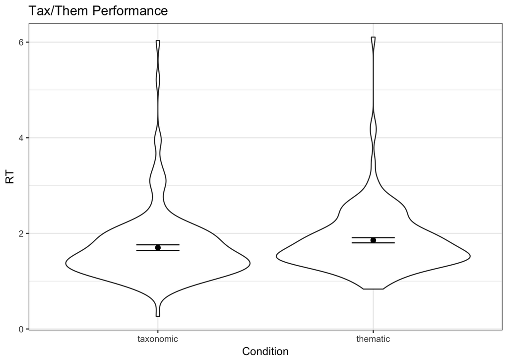

```r
# same RT processing as above
tt_rt <- test_trials %>%
  dplyr::filter(resp.corr == 1) %>%
  group_by(participant, Experiment) %>%
  mutate(mean_rt = mean(resp.rt),
         sd_rt = sd(resp.rt),
         diff = resp.rt-mean_rt,
         remove = ifelse(abs(diff) > 2*sd_rt, 1, 0)) %>%
  dplyr::filter(remove == 0) %>%
  summarise(m_rt = mean(resp.rt))

# violin plots by system
tt_plot_rt <- summarySE(tt_rt, "m_rt", "Experiment")
ggplot(tt_rt, aes(Experiment, m_rt)) + geom_violin() +
  geom_point(aes(y = m_rt), size = 2, position = position_dodge((width = 0.90)), data = tt_plot_rt) +
  geom_errorbar(aes(ymin = m_rt-se, ymax = m_rt+se), width = 0.20, position = position_dodge((width = 0.90)), data = tt_plot_rt) +
  theme_bw() + xlab("Condition") + ylab("RT") + ggtitle("Tax/Them Performance")
```

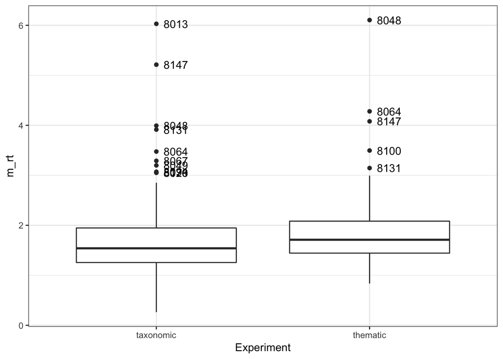

```r
# outlier plot
tt_rt %>%
  group_by(Experiment) %>%
  mutate(outlier = ifelse(is_outlier(m_rt), participant, as.numeric(NA))) %>%
  ggplot(., aes(Experiment, m_rt)) + geom_boxplot() + geom_text(aes(label = outlier), na.rm = TRUE, hjust = -0.3) + theme_bw()
```

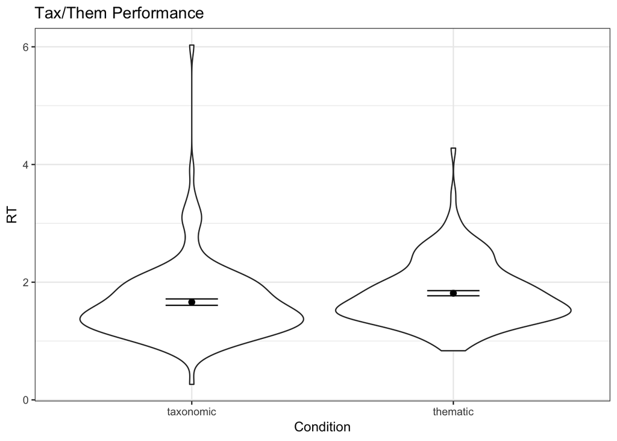

```r
# 8147 and 8048 are clear outliers in both conditions, so I will remove them.
tt_rt <- dplyr::filter(tt_rt, participant != 8147, participant != 8048)

# violin plot by system
tt_plot_rt <- summarySE(tt_rt, "m_rt", "Experiment")
ggplot(tt_rt, aes(Experiment, m_rt)) + geom_violin() +
  geom_point(aes(y = m_rt), size = 2, position = position_dodge((width = 0.90)), data = tt_plot_rt) +
  geom_errorbar(aes(ymin = m_rt-se, ymax = m_rt+se), width = 0.20, position = position_dodge((width = 0.90)), data = tt_plot_rt) +
  theme_bw() + xlab("Condition") + ylab("RT") + ggtitle("Tax/Them Performance")
```

Create *z*-scores for RT

```r
# new df
tt_rt_stand <- tt_rt
# rename column
colnames(tt_rt_stand)[1] <- "Subject"
# z-score
tt_rt_stand$rt_z <- scale(tt_rt_stand$m_rt)
# column for system
tt_rt_stand$System <- NA
tt_rt_stand$System[tt_rt_stand$Experiment == "taxonomic"] <- "hypothesis-testing"
tt_rt_stand$System[tt_rt_stand$Experiment == "thematic"] <- "associative"
# column for paradigm
tt_rt_stand$CatLearn <- "tt"
# df for raw rts
tt_rt <- tt_rt_stand[,-c(2,4)]
# df for rt z-scores
tt_rt_stand <- tt_rt_stand[,-c(2,3)]
```

# Combining the 3 experiments

## Accuracy

```r
# merge the data frames together
acc_long <- dplyr::bind_rows(ashby_acc_stand, slout_acc_stand, tt_acc_stand)
acc_wide <- acc_long %>%
  spread(key = CatLearn, value = acc_z) %>%
  na.omit

# find which subjects have full data for both systems and only use those subjects
both_systems <- acc_wide$Subject[duplicated(acc_wide$Subject)]
acc_wide <- dplyr::filter(acc_wide, Subject %in% both_systems)

# test the normality of the different variables
dagoTest(acc_wide$ashby)
```

```
##
## Title:
##  D'Agostino Normality Test
##
## Test Results:
##   STATISTIC:
##     Chi2 | Omnibus: 289.066
##     Z3  | Skewness: 1.6895
##     Z4  | Kurtosis: -16.9178
##   P VALUE:
##     Omnibus  Test: < 2.2e-16
##     Skewness Test: 0.09112
##     Kurtosis Test: < 2.2e-16
##
## Description:
##  Tue Feb  5 17:46:05 2019 by user:
```

```r
dagoTest(acc_wide$sloutsky)
```

```
##
## Title:
##  D'Agostino Normality Test
##
## Test Results:
##   STATISTIC:
##     Chi2 | Omnibus: 154.1194
##     Z3  | Skewness: -10.2946
##     Z4  | Kurtosis: 6.9384
##   P VALUE:
##     Omnibus  Test: < 2.2e-16
##     Skewness Test: < 2.2e-16
##     Kurtosis Test: 3.966e-12
##
## Description:
##  Tue Feb  5 17:46:05 2019 by user:
```

```r
dagoTest(acc_wide$tt)
```

```
##
## Title:
##  D'Agostino Normality Test
##
## Test Results:
##   STATISTIC:
##     Chi2 | Omnibus: 83.6945
##     Z3  | Skewness: -7.7055
##     Z4  | Kurtosis: 4.9315
##   P VALUE:
##     Omnibus  Test: < 2.2e-16
##     Skewness Test: 1.31e-14
##     Kurtosis Test: 8.159e-07
##
## Description:
##  Tue Feb  5 17:46:05 2019 by user:
```

```r
# sloutsky and tt are skewed, so let's transform. ashby is almost skewed, why not.
vars_tf <- c("ashby","sloutsky", "tt")
# transformations
pp_md_tf <- caret::preProcess(as.data.frame(acc_wide[,vars_tf]), method = c("center", "scale", "YeoJohnson"), na.remove=T)
tf_data <- predict(pp_md_tf, as.data.frame(acc_wide[,vars_tf]))
# re-check normality
dagoTest(tf_data$ashby)
```

```
##
## Title:
##  D'Agostino Normality Test
##
## Test Results:
##   STATISTIC:
##     Chi2 | Omnibus: 293.2158
##     Z3  | Skewness: 0.3838
##     Z4  | Kurtosis: -17.1192
##   P VALUE:
##     Omnibus  Test: < 2.2e-16
##     Skewness Test: 0.7011
##     Kurtosis Test: < 2.2e-16
##
## Description:
##  Tue Feb  5 17:46:05 2019 by user:
```

```r
dagoTest(tf_data$sloutsky)
```

```
##
## Title:
##  D'Agostino Normality Test
##
## Test Results:
##   STATISTIC:
##     Chi2 | Omnibus: 44.4129
##     Z3  | Skewness: -3.097
##     Z4  | Kurtosis: -5.901
##   P VALUE:
##     Omnibus  Test: 2.269e-10
##     Skewness Test: 0.001955
##     Kurtosis Test: 3.614e-09
##
## Description:
##  Tue Feb  5 17:46:05 2019 by user:
```

```r
dagoTest(tf_data$tt)
```

```
##
## Title:
##  D'Agostino Normality Test
##
## Test Results:
##   STATISTIC:
##     Chi2 | Omnibus: 8.9809
##     Z3  | Skewness: -0.6637
##     Z4  | Kurtosis: -2.9224
##   P VALUE:
##     Omnibus  Test: 0.01122
##     Skewness Test: 0.5069
##     Kurtosis Test: 0.003473
##
## Description:
##  Tue Feb  5 17:46:05 2019 by user:
```

```r
# less skewed at least

# move data into main data frame
acc_wide$ashby.t <- tf_data$ashby
acc_wide$sloutsky.t <- tf_data$sloutsky
acc_wide$tt.t <- tf_data$tt

write.csv(acc_wide, "catlearn_proc_acc.csv")

# merge in age and gender
acc_demo <- acc_wide %>%
  inner_join(.,age_gender, by = "Subject")

# only select first 84 subjects (per preregistration)
acc_sel <- acc_demo[c(1:(2*84)),]


acc_sel$Gender[acc_sel$Gender == "female"] <- "Female"
acc_sel$Gender[acc_sel$Gender == "male"] <- "Male"
# demographics for this sample
acc_sel %>%
  distinct(Subject, Age, Gender) %>%
  group_by(Gender) %>%
  dplyr::count(Gender)
```

```
## # A tibble: 2 x 2
## # Groups:   Gender [2]
##   Gender     n
##   <fct>  <int>
## 1 Female    61
## 2 Male      23
```

```r
acc_sel %>%
  distinct(Subject, Age, Gender) %>%
  ungroup() %>%
  summarise(m_age = mean(Age),
            sd_age = sd(Age),
            min_age = min(Age),
            max_age = max(Age))
```

```
## # A tibble: 1 x 4
##   m_age sd_age min_age max_age
##   <dbl>  <dbl>   <dbl>   <dbl>
## 1  18.4  0.867      17      21
```

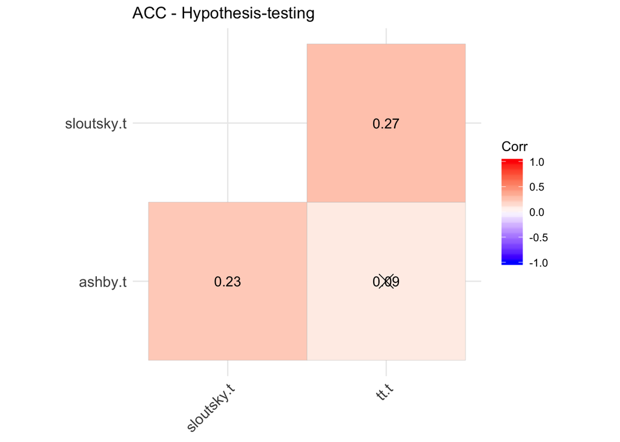

```r
# select only the hypothesis testing data and see their correlation
ht <- subset(acc_sel, System == "hypothesis-testing")
cor.mat <- cor(ht[,c(6:8)])
p.mat <- cor_pmat(ht[,c(6:8)])
ggcorrplot(cor.mat, type = "lower", p.mat = p.mat, lab = TRUE, title = "ACC - Hypothesis-testing")
```

```r
# same with associative
as <- subset(acc_sel, System == "associative")
cor(as[,c(6:8)])
```

```
##               ashby.t  sloutsky.t        tt.t
## ashby.t    1.00000000 0.121655906 0.050125962
## sloutsky.t 0.12165591 1.000000000 0.009214887
## tt.t       0.05012596 0.009214887 1.000000000
```

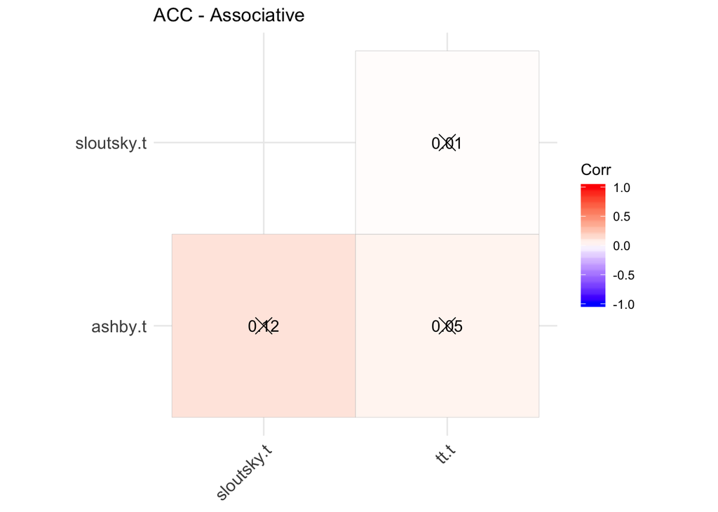

```r
cor.mat <- cor(as[,c(6:8)])
p.mat <- cor_pmat(as[,c(6:8)])
ggcorrplot(cor.mat, type = "lower", p.mat = p.mat, lab = TRUE, title = "ACC - Associative")
```

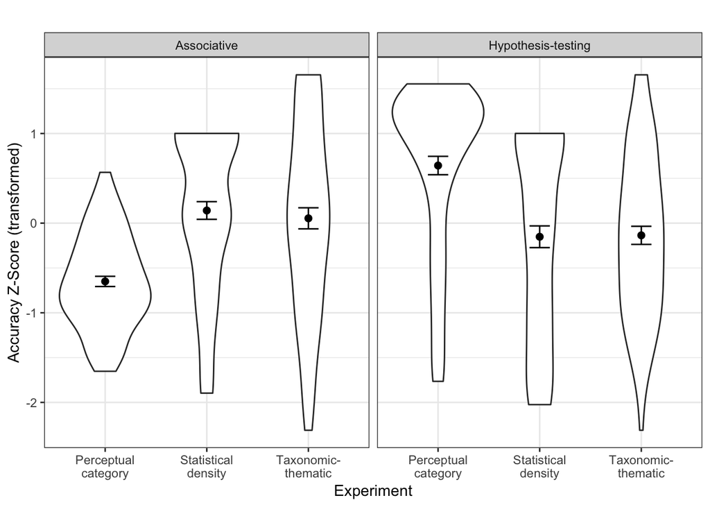

```r
# Plot accuracy
acc_sel_long <- acc_sel %>%
  dplyr::select(Subject, System, ashby.t:tt.t) %>%
  gather(key ="CatLearn", value = "acc_z", ashby.t:tt.t)

acc_sel_long <- acc_sel_long %>%
  mutate(CatLearn = revalue(CatLearn, c("ashby.t" = "Perceptual\ncategory", "sloutsky.t" = "Statistical\ndensity", "tt.t" = "Taxonomic-\nthematic")),
         System = revalue(System, c("associative" = "Associative", "hypothesis-testing" = "Hypothesis-testing")))


# by system
acc_all_plot <- summarySE(acc_sel_long, "acc_z", c("System", "CatLearn"))
ggplot(acc_sel_long, aes(CatLearn, acc_z)) + geom_violin() +
  geom_point(aes(y = acc_z), size = 2, position = position_dodge((width = 0.90)), data = acc_all_plot) +
  geom_errorbar(aes(ymin = acc_z-se, ymax = acc_z+se), width = 0.20, position = position_dodge((width = 0.90)), data = acc_all_plot) +
  facet_grid(.~System) +
  theme_bw() + xlab("Experiment") + ylab("Accuracy Z-Score (transformed)") + ggtitle("")
```

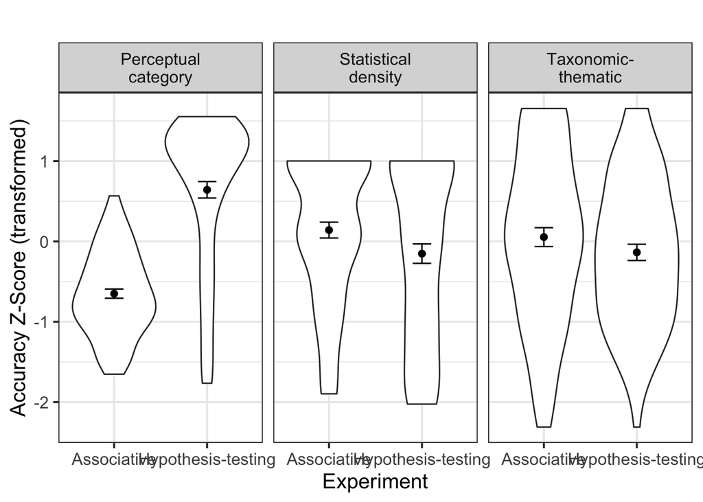

```r
# by paradigm
ggplot(acc_sel_long, aes(System, acc_z)) + geom_violin() +
  geom_point(aes(y = acc_z), size = 2, position = position_dodge((width = 0.90)), data = acc_all_plot) +
  geom_errorbar(aes(ymin = acc_z-se, ymax = acc_z+se), width = 0.20, position = position_dodge((width = 0.90)), data = acc_all_plot) +
  facet_grid(.~CatLearn) +
  theme_bw(15) + xlab("Experiment") + ylab("Accuracy Z-Score (transformed)") + ggtitle("")
```

```r
# run basic models
m0 <- lmer(acc_z ~ 1 + (1|Subject), data = acc_sel_long)
ranova(m0)
```

```
## ANOVA-like table for random-effects: Single term deletions
##
## Model:
## acc_z ~ (1 | Subject)
##               npar  logLik    AIC    LRT Df Pr(>Chisq)
## <none>           3 -716.84 1439.7
## (1 | Subject)    2 -719.75 1443.5 5.8125  1    0.01591 *
## ---
## Signif. codes:  0 '***' 0.001 '**' 0.01 '*' 0.05 '.' 0.1 ' ' 1
```

```r
m1 <- lmer(acc_z ~ CatLearn + System + (1|Subject), data = acc_sel_long)
anova(m0,m1)
```

```
## Data: acc_sel_long
## Models:
## m0: acc_z ~ 1 + (1 | Subject)
## m1: acc_z ~ CatLearn + System + (1 | Subject)
##    Df    AIC    BIC  logLik deviance  Chisq Chi Df Pr(>Chisq)
## m0  3 1435.6 1448.3 -714.81   1429.6
## m1  6 1431.5 1456.9 -709.78   1419.5 10.067      3    0.01801 *
## ---
## Signif. codes:  0 '***' 0.001 '**' 0.01 '*' 0.05 '.' 0.1 ' ' 1
```

```r
m2 <- lmer(acc_z ~ CatLearn * System + (1|Subject), data = acc_sel_long)
anova(m1,m2)
```

```
## Data: acc_sel_long
## Models:
## m1: acc_z ~ CatLearn + System + (1 | Subject)
## m2: acc_z ~ CatLearn * System + (1 | Subject)
##    Df    AIC    BIC  logLik deviance  Chisq Chi Df Pr(>Chisq)
## m1  6 1431.5 1456.9 -709.78   1419.5
## m2  8 1356.2 1390.0 -670.11   1340.2 79.334      2  < 2.2e-16 ***
## ---
## Signif. codes:  0 '***' 0.001 '**' 0.01 '*' 0.05 '.' 0.1 ' ' 1
```

```r
summary(m2)
```

```
## Linear mixed model fit by REML. t-tests use Satterthwaite's method [
## lmerModLmerTest]
## Formula: acc_z ~ CatLearn * System + (1 | Subject)
##    Data: acc_sel_long
##
## REML criterion at convergence: 1356.8
##
## Scaled residuals:
##     Min      1Q  Median      3Q     Max
## -2.8617 -0.6444  0.1189  0.7492  2.0660
##
## Random effects:
##  Groups   Name        Variance Std.Dev.
##  Subject  (Intercept) 0.1035   0.3217
##  Residual             0.7667   0.8756
## Number of obs: 504, groups:  Subject, 84
##
## Fixed effects:
##                                                       Estimate Std. Error
## (Intercept)                                            -0.6500     0.1018
## CatLearnStatistical\ndensity                            0.7912     0.1351
## CatLearnTaxonomic-\nthematic                            0.7040     0.1351
## SystemHypothesis-testing                                1.2928     0.1351
## CatLearnStatistical\ndensity:SystemHypothesis-testing  -1.5861     0.1911
## CatLearnTaxonomic-\nthematic:SystemHypothesis-testing  -1.4829     0.1911
##                                                             df t value
## (Intercept)                                           465.1054  -6.386
## CatLearnStatistical\ndensity                          415.0000   5.856
## CatLearnTaxonomic-\nthematic                          415.0000   5.210
## SystemHypothesis-testing                              415.0000   9.568
## CatLearnStatistical\ndensity:SystemHypothesis-testing 415.0000  -8.301
## CatLearnTaxonomic-\nthematic:SystemHypothesis-testing 415.0000  -7.761
##                                                       Pr(>|t|)
## (Intercept)                                           4.13e-10 ***
## CatLearnStatistical\ndensity                          9.66e-09 ***
## CatLearnTaxonomic-\nthematic                          2.98e-07 ***
## SystemHypothesis-testing                               < 2e-16 ***
## CatLearnStatistical\ndensity:SystemHypothesis-testing 1.47e-15 ***
## CatLearnTaxonomic-\nthematic:SystemHypothesis-testing 6.65e-14 ***
## ---
## Signif. codes:  0 '***' 0.001 '**' 0.01 '*' 0.05 '.' 0.1 ' ' 1
##
## Correlation of Fixed Effects:
##             (Intr) CtLrSd CtLT-t SystH- CLSd:S
## CtLrnSttstd -0.664
## CtLrnTxnm-t -0.664  0.500
## SystmHypth- -0.664  0.500  0.500
## CtLrnSd:SH-  0.469 -0.707 -0.354 -0.707
## CtLrT-t:SH-  0.469 -0.354 -0.707 -0.707  0.500
```

```r
anova(m2)
```

```
## Type III Analysis of Variance Table with Satterthwaite's method
##                 Sum Sq Mean Sq NumDF DenDF F value    Pr(>F)
## CatLearn         0.150   0.075     2   415  0.0977 0.9069467
## System           9.174   9.174     1   415 11.9648 0.0005983 ***
## CatLearn:System 66.155  33.078     2   415 43.1409 < 2.2e-16 ***
## ---
## Signif. codes:  0 '***' 0.001 '**' 0.01 '*' 0.05 '.' 0.1 ' ' 1
```

```r
# break down interaction between paradigm and system
ashby_subset <- acc_sel_long$CatLearn=="Perceptual\ncategory"
sloutsky_subset <- acc_sel_long$CatLearn=="Statistical\ndensity"
tt_subset <- acc_sel_long$CatLearn=="Taxonomic-\nthematic"

# check ashby first
ashby_model <- lmer(acc_z ~ System + (1|Subject), data = acc_sel_long, subset = ashby_subset)
summary(ashby_model)
```

```
## Linear mixed model fit by REML. t-tests use Satterthwaite's method [
## lmerModLmerTest]
## Formula: acc_z ~ System + (1 | Subject)
##    Data: acc_sel_long
##  Subset: ashby_subset
##
## REML criterion at convergence: 377.4
##
## Scaled residuals:
##     Min      1Q  Median      3Q     Max
## -2.9139 -0.3683  0.1623  0.6520  1.2580
##
## Random effects:
##  Groups   Name        Variance Std.Dev.
##  Subject  (Intercept) 0.2128   0.4613
##  Residual             0.3668   0.6056
## Number of obs: 168, groups:  Subject, 84
##
## Fixed effects:
##                           Estimate Std. Error        df t value Pr(>|t|)
## (Intercept)               -0.64999    0.08306 146.28421  -7.826 9.31e-13
## SystemHypothesis-testing   1.29283    0.09345  83.00000  13.835  < 2e-16
##
## (Intercept)              ***
## SystemHypothesis-testing ***
## ---
## Signif. codes:  0 '***' 0.001 '**' 0.01 '*' 0.05 '.' 0.1 ' ' 1
##
## Correlation of Fixed Effects:
##             (Intr)
## SystmHypth- -0.563
```

```r
anova(ashby_model)
```

```
## Type III Analysis of Variance Table with Satterthwaite's method
##        Sum Sq Mean Sq NumDF DenDF F value    Pr(>F)
## System 70.199  70.199     1    83   191.4 < 2.2e-16 ***
## ---
## Signif. codes:  0 '***' 0.001 '**' 0.01 '*' 0.05 '.' 0.1 ' ' 1
```

```r
# look at post hocs
summary(glht(ashby_model, linfct = mcp(System = "Tukey")), test = adjusted("holm"))
```

```
##
##   Simultaneous Tests for General Linear Hypotheses
##
## Multiple Comparisons of Means: Tukey Contrasts
##
##
## Fit: lmer(formula = acc_z ~ System + (1 | Subject), data = acc_sel_long,
##     subset = ashby_subset)
##
## Linear Hypotheses:
##                                       Estimate Std. Error z value Pr(>|z|)
## Hypothesis-testing - Associative == 0  1.29283    0.09345   13.84   <2e-16
##
## Hypothesis-testing - Associative == 0 ***
## ---
## Signif. codes:  0 '***' 0.001 '**' 0.01 '*' 0.05 '.' 0.1 ' ' 1
## (Adjusted p values reported -- holm method)
```

```r
# sloutsky
sloutsky_model <- lmer(acc_z ~ System + (1|Subject), data = acc_sel_long, subset = sloutsky_subset)
summary(sloutsky_model)
```

```
## Linear mixed model fit by REML. t-tests use Satterthwaite's method [
## lmerModLmerTest]
## Formula: acc_z ~ System + (1 | Subject)
##    Data: acc_sel_long
##  Subset: sloutsky_subset
##
## REML criterion at convergence: 483.6
##
## Scaled residuals:
##     Min      1Q  Median      3Q     Max
## -2.0154 -0.7555  0.1055  0.8505  1.1406
##
## Random effects:
##  Groups   Name        Variance  Std.Dev.
##  Subject  (Intercept) 3.079e-16 1.755e-08
##  Residual             1.022e+00 1.011e+00
## Number of obs: 168, groups:  Subject, 84
##
## Fixed effects:
##                          Estimate Std. Error       df t value Pr(>|t|)
## (Intercept)                0.1412     0.1103 166.0000    1.28   0.2023
## SystemHypothesis-testing  -0.2933     0.1560 166.0000   -1.88   0.0619 .
## ---
## Signif. codes:  0 '***' 0.001 '**' 0.01 '*' 0.05 '.' 0.1 ' ' 1
##
## Correlation of Fixed Effects:
##             (Intr)
## SystmHypth- -0.707
```

```r
anova(sloutsky_model)
```

```
## Type III Analysis of Variance Table with Satterthwaite's method
##        Sum Sq Mean Sq NumDF DenDF F value  Pr(>F)
## System 3.6129  3.6129     1   166  3.5341 0.06187 .
## ---
## Signif. codes:  0 '***' 0.001 '**' 0.01 '*' 0.05 '.' 0.1 ' ' 1
```

```r
# look at post hocs
summary(glht(sloutsky_model, linfct = mcp(System = "Tukey")), test = adjusted("holm"))
```

```
##
##   Simultaneous Tests for General Linear Hypotheses
##
## Multiple Comparisons of Means: Tukey Contrasts
##
##
## Fit: lmer(formula = acc_z ~ System + (1 | Subject), data = acc_sel_long,
##     subset = sloutsky_subset)
##
## Linear Hypotheses:
##                                       Estimate Std. Error z value Pr(>|z|)
## Hypothesis-testing - Associative == 0  -0.2933     0.1560   -1.88   0.0601
##
## Hypothesis-testing - Associative == 0 .
## ---
## Signif. codes:  0 '***' 0.001 '**' 0.01 '*' 0.05 '.' 0.1 ' ' 1
## (Adjusted p values reported -- holm method)
```

```r
# tt
tt_model <- lmer(acc_z ~ System + (1|Subject), data = acc_sel_long, subset = tt_subset)
summary(tt_model)
```

```
## Linear mixed model fit by REML. t-tests use Satterthwaite's method [
## lmerModLmerTest]
## Formula: acc_z ~ System + (1 | Subject)
##    Data: acc_sel_long
##  Subset: tt_subset
##
## REML criterion at convergence: 466.8
##
## Scaled residuals:
##      Min       1Q   Median       3Q      Max
## -2.58698 -0.55853  0.04786  0.54990  2.27157
##
## Random effects:
##  Groups   Name        Variance Std.Dev.
##  Subject  (Intercept) 0.4051   0.6365
##  Residual             0.6038   0.7770
## Number of obs: 168, groups:  Subject, 84
##
## Fixed effects:
##                           Estimate Std. Error        df t value Pr(>|t|)
## (Intercept)                0.05398    0.10959 142.95248   0.493    0.623
## SystemHypothesis-testing  -0.19005    0.11990  83.00000  -1.585    0.117
##
## Correlation of Fixed Effects:
##             (Intr)
## SystmHypth- -0.547
```

```r
anova(tt_model)
```

```
## Type III Analysis of Variance Table with Satterthwaite's method
##        Sum Sq Mean Sq NumDF DenDF F value Pr(>F)
## System 1.5169  1.5169     1    83  2.5124 0.1168
```

```r
# look at post hocs
summary(glht(tt_model, linfct = mcp(System = "Tukey")), test = adjusted("holm"))
```

```
##
##   Simultaneous Tests for General Linear Hypotheses
##
## Multiple Comparisons of Means: Tukey Contrasts
##
##
## Fit: lmer(formula = acc_z ~ System + (1 | Subject), data = acc_sel_long,
##     subset = tt_subset)
##
## Linear Hypotheses:
##                                       Estimate Std. Error z value Pr(>|z|)
## Hypothesis-testing - Associative == 0  -0.1900     0.1199  -1.585    0.113
## (Adjusted p values reported -- holm method)
```

There’s no main effect of CatLearn, suggesting that average (standardized) ACC across models is the same. The results are really showing a ceiling effect – we don’t see many differences between HT and AS for sloutsky and tax-them because they’re easy! So, we can look at RT instead.

## RT

```r
# bring together RT data
rt_long <- dplyr::bind_rows(ashby_rt_stand, slout_rt_stand, tt_rt_stand)

# make a wide dataset
rt_wide <- rt_long %>%
  spread(key = CatLearn, value = rt_z) %>%
  na.omit

# find which subjects have both systems and keep those
both_systems <- rt_wide$Subject[duplicated(rt_wide$Subject)]
rt_wide <- dplyr::filter(rt_wide, Subject %in% both_systems)

# check normality
dagoTest(rt_wide$ashby)
```

```
##
## Title:
##  D'Agostino Normality Test
##
## Test Results:
##   STATISTIC:
##     Chi2 | Omnibus: 17.2428
##     Z3  | Skewness: 3.3473
##     Z4  | Kurtosis: 2.4574
##   P VALUE:
##     Omnibus  Test: 0.0001802
##     Skewness Test: 0.0008162
##     Kurtosis Test: 0.014
##
## Description:
##  Tue Feb  5 17:46:10 2019 by user:
```

```r
dagoTest(rt_wide$sloutsky)
```

```
##
## Title:
##  D'Agostino Normality Test
##
## Test Results:
##   STATISTIC:
##     Chi2 | Omnibus: 25.48
##     Z3  | Skewness: 4.87
##     Z4  | Kurtosis: 1.3278
##   P VALUE:
##     Omnibus  Test: 2.931e-06
##     Skewness Test: 1.116e-06
##     Kurtosis Test: 0.1843
##
## Description:
##  Tue Feb  5 17:46:10 2019 by user:
```

```r
dagoTest(rt_wide$tt)
```

```
##
## Title:
##  D'Agostino Normality Test
##
## Test Results:
##   STATISTIC:
##     Chi2 | Omnibus: 116.4705
##     Z3  | Skewness: 8.3404
##     Z4  | Kurtosis: 6.8489
##   P VALUE:
##     Omnibus  Test: < 2.2e-16
##     Skewness Test: < 2.2e-16
##     Kurtosis Test: 7.44e-12
##
## Description:
##  Tue Feb  5 17:46:10 2019 by user:
```

```r
# all are very skewed. transform.
vars_tf <- c("ashby", "sloutsky", "tt")
pp_md_tf <- preProcess(as.data.frame(rt_wide[,vars_tf]), method = c("center", "scale", "YeoJohnson"), na.remove=T)
tf_data <- predict(pp_md_tf, as.data.frame(rt_wide[,vars_tf]))

# re-check normality
dagoTest(tf_data$ashby)
```

```
##
## Title:
##  D'Agostino Normality Test
##
## Test Results:
##   STATISTIC:
##     Chi2 | Omnibus: 4.4859
##     Z3  | Skewness: -0.5124
##     Z4  | Kurtosis: 2.0551
##   P VALUE:
##     Omnibus  Test: 0.1061
##     Skewness Test: 0.6084
##     Kurtosis Test: 0.03987
##
## Description:
##  Tue Feb  5 17:46:10 2019 by user:
```

```r
dagoTest(tf_data$sloutsky)
```

```
##
## Title:
##  D'Agostino Normality Test
##
## Test Results:
##   STATISTIC:
##     Chi2 | Omnibus: 3.557
##     Z3  | Skewness: 0.222
##     Z4  | Kurtosis: -1.8729
##   P VALUE:
##     Omnibus  Test: 0.1689
##     Skewness Test: 0.8243
##     Kurtosis Test: 0.06108
##
## Description:
##  Tue Feb  5 17:46:10 2019 by user:
```

```r
dagoTest(tf_data$tt)
```

```
##
## Title:
##  D'Agostino Normality Test
##
## Test Results:
##   STATISTIC:
##     Chi2 | Omnibus: 0.3355
##     Z3  | Skewness: 0.1618
##     Z4  | Kurtosis: 0.5562
##   P VALUE:
##     Omnibus  Test: 0.8456
##     Skewness Test: 0.8714
##     Kurtosis Test: 0.5781
##
## Description:
##  Tue Feb  5 17:46:10 2019 by user:
```

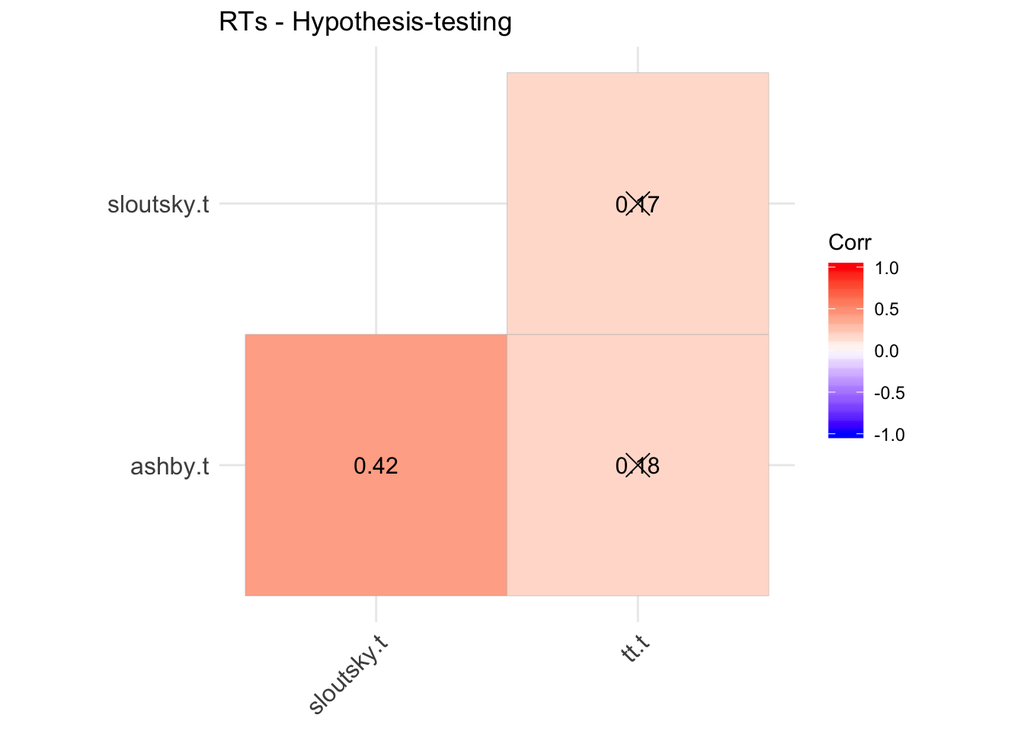

```r
# way better!

# add to main dataframe
rt_wide$ashby.t <- tf_data$ashby
rt_wide$sloutsky.t <- tf_data$sloutsky
rt_wide$tt.t <- tf_data$tt

write.csv(rt_wide, "catlearn_proc_rt.csv")

# select only first 84 subjects (per preregistration)
rt_sel <- rt_wide[c(1:(2*84)),]

# look at correlations
# first for hypothesis-testing
ht <- subset(rt_sel, System == "hypothesis-testing")
cor.mat <- cor(ht[,c(6:8)])
p.mat <- cor_pmat(ht[,c(6:8)])
ggcorrplot(cor.mat, type = "lower", p.mat = p.mat, lab = TRUE, title = "RTs - Hypothesis-testing")
```

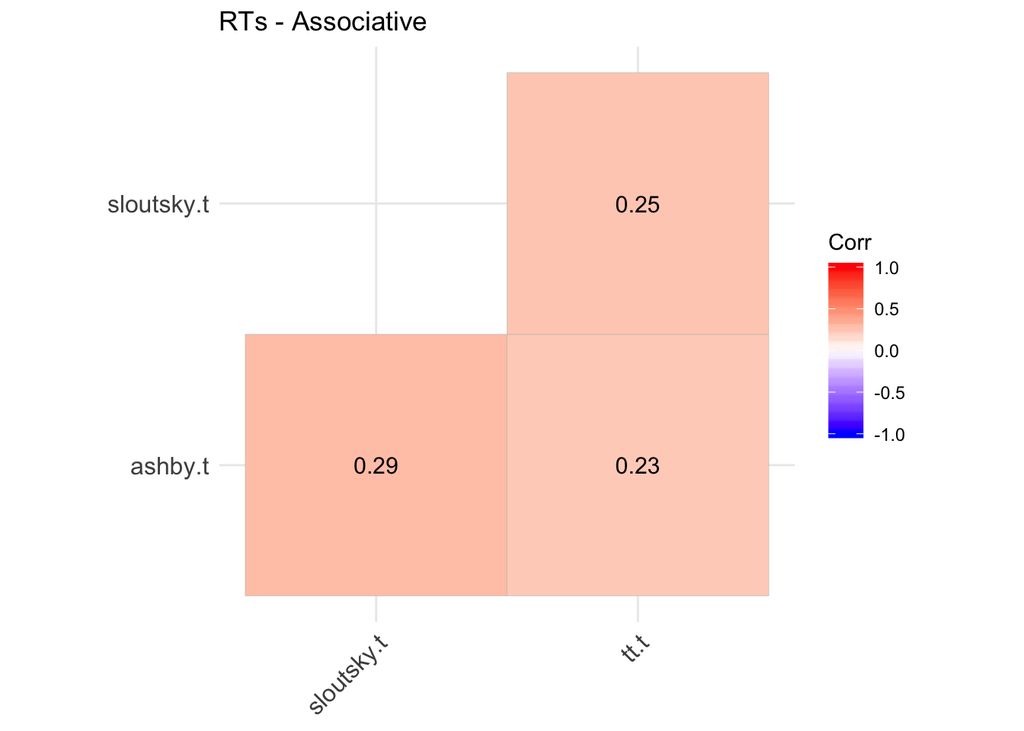

```r
# now hypothesis testing
as <- subset(rt_sel, System == "associative")
cor.mat <- cor(as[,c(6:8)])
p.mat <- cor_pmat(as[,c(6:8)])
ggcorrplot(cor.mat, type = "lower", p.mat = p.mat, lab = TRUE, title = "RTs - Associative")
```

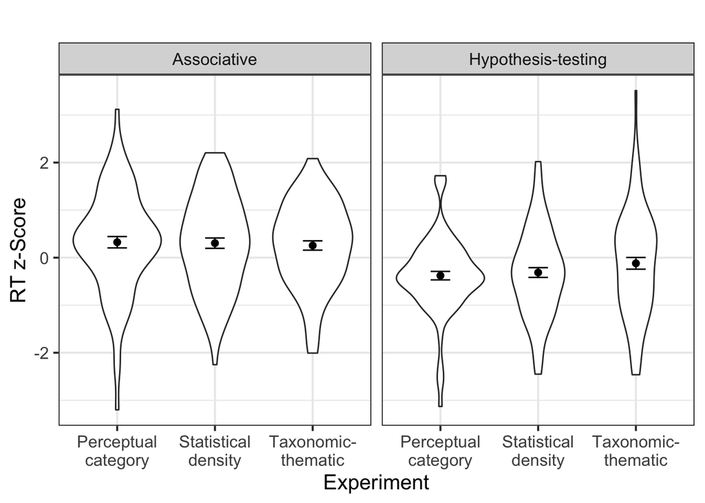

```r
rt_sel_long <- rt_sel %>%
  dplyr::select(Subject, System, ashby.t:tt.t) %>%
  gather(key ="CatLearn", value = "rt_z", ashby.t:tt.t)

rt_sel_long <- rt_sel_long %>%
  mutate(CatLearn = revalue(CatLearn, c("ashby.t" = "Perceptual\ncategory", "sloutsky.t" = "Statistical\ndensity", "tt.t" = "Taxonomic-\nthematic")),
         System = revalue(System, c("associative" = "Associative", "hypothesis-testing" = "Hypothesis-testing")))

# now plot
# first by system
rt_all_plot <- summarySE(rt_sel_long, "rt_z", c("System", "CatLearn"))
ggplot(rt_sel_long, aes(CatLearn, rt_z)) + geom_violin() +
  geom_point(aes(y = rt_z), size = 2, position = position_dodge((width = 0.90)), data = rt_all_plot) +
  geom_errorbar(aes(ymin = rt_z-se, ymax = rt_z+se), width = 0.20, position = position_dodge((width = 0.90)), data = rt_all_plot) +
  facet_grid(.~System) +
  theme_bw(15) + xlab("Experiment") + ylab("RT z-Score") + ggtitle("")
```

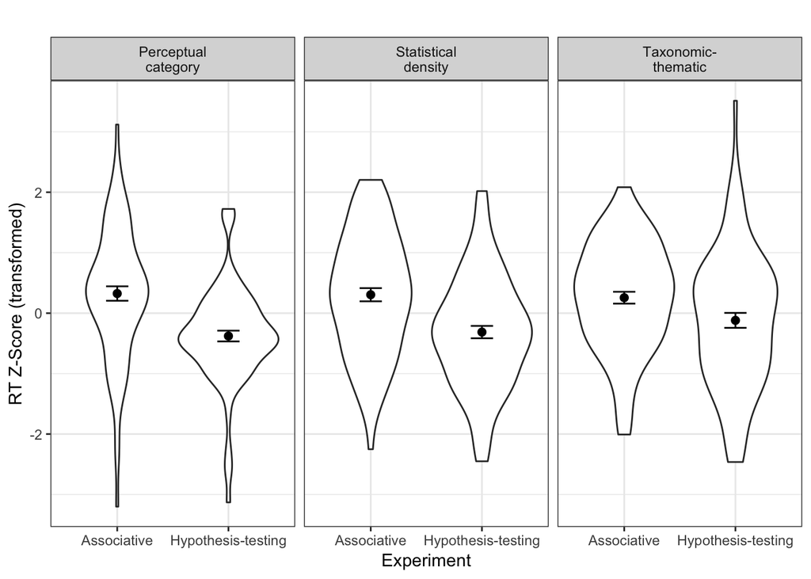

```r
# then by paradigm
ggplot(rt_sel_long, aes(System, rt_z)) + geom_violin() +
  geom_point(aes(y = rt_z), size = 2, position = position_dodge((width = 0.90)), data = rt_all_plot) +
  geom_errorbar(aes(ymin = rt_z-se, ymax = rt_z+se), width = 0.20, position = position_dodge((width = 0.90)), data = rt_all_plot) +
  facet_grid(.~CatLearn) +
  theme_bw() + xlab("Experiment") + ylab("RT Z-Score (transformed)") + ggtitle("")
```

```r
m0 <- lmer(rt_z ~ 1 + (1|Subject), data = rt_sel_long)
ranova(m0)
```

```
## ANOVA-like table for random-effects: Single term deletions
##
## Model:
## rt_z ~ (1 | Subject)
##               npar  logLik    AIC    LRT Df Pr(>Chisq)
## <none>           3 -696.21 1398.4
## (1 | Subject)    2 -728.36 1460.7 64.313  1  1.061e-15 ***
## ---
## Signif. codes:  0 '***' 0.001 '**' 0.01 '*' 0.05 '.' 0.1 ' ' 1
```

```r
m1 <- lmer(rt_z ~ CatLearn + System + (1|Subject), data = rt_sel_long)
anova(m0,m1)
```

```
## Data: rt_sel_long
## Models:
## m0: rt_z ~ 1 + (1 | Subject)
## m1: rt_z ~ CatLearn + System + (1 | Subject)
##    Df    AIC    BIC  logLik deviance  Chisq Chi Df Pr(>Chisq)
## m0  3 1395.0 1407.6 -694.47   1389.0
## m1  6 1342.7 1368.0 -665.32   1330.7 58.298      3  1.357e-12 ***
## ---
## Signif. codes:  0 '***' 0.001 '**' 0.01 '*' 0.05 '.' 0.1 ' ' 1
```

```r
m2 <- lmer(rt_z ~ CatLearn * System + (1|Subject), data = rt_sel_long)
anova(m1,m2)
```

```
## Data: rt_sel_long
## Models:
## m1: rt_z ~ CatLearn + System + (1 | Subject)
## m2: rt_z ~ CatLearn * System + (1 | Subject)
##    Df    AIC    BIC  logLik deviance  Chisq Chi Df Pr(>Chisq)
## m1  6 1342.7 1368.0 -665.32   1330.7
## m2  8 1342.9 1376.7 -663.47   1326.9 3.7177      2     0.1558
```

```r
summary(m2)
```

```
## Linear mixed model fit by REML. t-tests use Satterthwaite's method [
## lmerModLmerTest]
## Formula: rt_z ~ CatLearn * System + (1 | Subject)
##    Data: rt_sel_long
##
## REML criterion at convergence: 1343.7
##
## Scaled residuals:
##     Min      1Q  Median      3Q     Max
## -3.3977 -0.5478  0.0285  0.5962  3.7122
##
## Random effects:
##  Groups   Name        Variance Std.Dev.
##  Subject  (Intercept) 0.311    0.5576
##  Residual             0.659    0.8118
## Number of obs: 504, groups:  Subject, 84
##
## Fixed effects:
##                                                        Estimate Std. Error
## (Intercept)                                             0.32451    0.10746
## CatLearnStatistical\ndensity                           -0.01965    0.12527
## CatLearnTaxonomic-\nthematic                           -0.06888    0.12527
## SystemHypothesis-testing                               -0.70283    0.12527
## CatLearnStatistical\ndensity:SystemHypothesis-testing   0.08488    0.17715
## CatLearnTaxonomic-\nthematic:SystemHypothesis-testing   0.32782    0.17715
##                                                              df t value
## (Intercept)                                           328.96252   3.020
## CatLearnStatistical\ndensity                          415.00000  -0.157
## CatLearnTaxonomic-\nthematic                          415.00000  -0.550
## SystemHypothesis-testing                              415.00000  -5.611
## CatLearnStatistical\ndensity:SystemHypothesis-testing 415.00000   0.479
## CatLearnTaxonomic-\nthematic:SystemHypothesis-testing 415.00000   1.851
##                                                       Pr(>|t|)
## (Intercept)                                            0.00273 **
## CatLearnStatistical\ndensity                           0.87541
## CatLearnTaxonomic-\nthematic                           0.58271
## SystemHypothesis-testing                              3.69e-08 ***
## CatLearnStatistical\ndensity:SystemHypothesis-testing  0.63212
## CatLearnTaxonomic-\nthematic:SystemHypothesis-testing  0.06495 .
## ---
## Signif. codes:  0 '***' 0.001 '**' 0.01 '*' 0.05 '.' 0.1 ' ' 1
##
## Correlation of Fixed Effects:
##             (Intr) CtLrSd CtLT-t SystH- CLSd:S
## CtLrnSttstd -0.583
## CtLrnTxnm-t -0.583  0.500
## SystmHypth- -0.583  0.500  0.500
## CtLrnSd:SH-  0.412 -0.707 -0.354 -0.707
## CtLrT-t:SH-  0.412 -0.354 -0.707 -0.707  0.500
```

```r
anova(m1)
```

```
## Type III Analysis of Variance Table with Satterthwaite's method
##          Sum Sq Mean Sq NumDF DenDF F value    Pr(>F)
## CatLearn  0.827   0.414     2   417   0.625    0.5358
## System   40.260  40.260     1   417  60.842 5.012e-14 ***
## ---
## Signif. codes:  0 '***' 0.001 '**' 0.01 '*' 0.05 '.' 0.1 ' ' 1
```

```r
summary(glht(m1, linfct = mcp(System = "Tukey")), test = adjusted("holm"))
```

```
##
##   Simultaneous Tests for General Linear Hypotheses
##
## Multiple Comparisons of Means: Tukey Contrasts
##
##
## Fit: lmer(formula = rt_z ~ CatLearn + System + (1 | Subject), data = rt_sel_long)
##
## Linear Hypotheses:
##                                       Estimate Std. Error z value Pr(>|z|)
## Hypothesis-testing - Associative == 0 -0.56527    0.07247    -7.8 6.22e-15
##
## Hypothesis-testing - Associative == 0 ***
## ---
## Signif. codes:  0 '***' 0.001 '**' 0.01 '*' 0.05 '.' 0.1 ' ' 1
## (Adjusted p values reported -- holm method)
```

We only see a main effect of system – where associative is consistently slower than hypothesis-testing.

## Descriptives

```r
# bind together raw ACC and RT dfs
acc <- dplyr::bind_rows(ashby_acc, slout_acc, tt_acc)
rt <- dplyr::bind_rows(ashby_rt, slout_rt, tt_rt)

# make them into wide dfs, omit missing cells
acc_wide <- acc %>%
  spread(key = CatLearn, value = m_acc) %>%
  na.omit

rt_wide <- rt %>%
  spread(key = CatLearn, value = m_rt) %>%
  na.omit

# make them long again, select only first 24 subjects
acc_group <- acc_wide[c(1:(2*84)),] %>%
  gather(key = "CatLearn", value = "m_acc", ashby:tt)
rt_group <- rt_wide[c(1:(2*84)),] %>%
  gather(key = "CatLearn", value = "m_rt", ashby:tt)

# merge together
data <- merge(acc_group, rt_group, by = c("Subject", "CatLearn", "System"))

# print out summary statistics
data %>%
  gather(key = "measure", value = "value", m_acc:m_rt) %>%
  group_by(CatLearn, measure, System) %>%
  summarise(m = mean(value),
            SD = sd(value),
            min = min(value),
            max = max(value))
```

```
## # A tibble: 12 x 7
## # Groups:   CatLearn, measure [?]
##    CatLearn measure System                 m     SD   min   max
##    <chr>    <chr>   <chr>              <dbl>  <dbl> <dbl> <dbl>
##  1 ashby    m_acc   associative        0.587 0.0675 0.462 0.762
##  2 ashby    m_acc   hypothesis-testing 0.800 0.148  0.45  0.958
##  3 ashby    m_rt    associative        0.791 0.219  0.206 1.53
##  4 ashby    m_rt    hypothesis-testing 0.653 0.157  0.215 1.12
##  5 sloutsky m_acc   associative        0.955 0.0819 0.6   1
##  6 sloutsky m_acc   hypothesis-testing 0.894 0.178  0.2   1
##  7 sloutsky m_rt    associative        0.783 0.210  0.422 1.32
##  8 sloutsky m_rt    hypothesis-testing 0.672 0.160  0.413 1.24
##  9 tt       m_acc   associative        0.841 0.164  0.208 1
## 10 tt       m_acc   hypothesis-testing 0.834 0.134  0.208 1
## 11 tt       m_rt    associative        1.89  0.524  0.918 3.50
## 12 tt       m_rt    hypothesis-testing 1.73  0.741  0.786 6.03
```

```r
# look at ceiling effects
acc_group %>%
  dplyr::filter(m_acc >= 0.9) %>%
  group_by(System, CatLearn) %>%
  summarise(count = n())
```

```
## # A tibble: 5 x 3
## # Groups:   System [?]
##   System             CatLearn count
##   <chr>              <chr>    <int>
## 1 associative        sloutsky    78
## 2 associative        tt          40
## 3 hypothesis-testing ashby       30
## 4 hypothesis-testing sloutsky    65
## 5 hypothesis-testing tt          32
```